# Notebook d'analyse de stabilité des segments

## Projet 3 parcours Ingénieur Machine Learning

Accès projet git : https://github.com/Adrian1903/Segmentez-des-clients-d-un-site-e-commerce-Formation-IML  
Plus d'informations : https://openclassrooms.com/fr/paths/148-ingenieur-machine-learning

# 0. Contexte

Vous êtes consultant pour Olist, une solution de vente sur les marketplaces en ligne.

Olist souhaite que vous fournissiez à ses équipes d'e-commerce une segmentation des clients qu’elles pourront utiliser au quotidien pour leurs campagnes de communication.

Votre objectif est de comprendre les différents types d’utilisateurs grâce à leur comportement et à leurs données personnelles.

Vous devrez fournir à l’équipe marketing une description actionable de votre segmentation et de sa logique sous-jacente pour une utilisation optimale, ainsi qu’une proposition de contrat de maintenance basée sur une analyse de la stabilité des segments au cours du temps.

### Les données

Pour cette mission, Olist vous fournit une base de données anonymisée comportant des informations sur l’historique de commandes, les produits achetés, les commentaires de satisfaction, et la localisation des clients depuis janvier 2017.

### Votre mission

Votre mission est d’aider les équipes d’Olist à comprendre les différents types d'utilisateurs. Vous utiliserez donc des méthodes non supervisées pour regrouper ensemble des clients de profils similaires. Ces catégories pourront être utilisées par l’équipe marketing pour mieux communiquer.

Pour des raisons de confidentialité, Olist ne fournit pas beaucoup de données, à vous de fouiller dans celles dont vous disposez et de créer les meilleures features pour les exploiter.

Enfin, votre client, Olist, a spécifié sa demande ainsi :

- La segmentation proposée doit être exploitable et facile d’utilisation pour l’équipe marketing.
- Vous évaluerez la fréquence à laquelle la segmentation doit être mise à jour, afin de pouvoir effectuer un devis de contrat de maintenance.
- Le code fourni doit respecter la convention PEP8, pour être utilisable par Olist.

L'objectif, ici, est d'évaluer la stabilité des segments au cours du temps dans le but de proposer un contrat de maintenance.

# 1. Importation et exploration préliminaire

```python
import pandas as pd

import datetime as dt

from sklearn.preprocessing import StandardScaler
from sklearn.cluster import KMeans

import plotly.graph_objects as go
import plotly

from IPython.display import Image

from functions import *

pd.options.display.max_columns = None
plt.style.use("default")
```

```python
# Pour vérifier le respect de la convention PEP8
# Installation conda non diponible. Utiliser pip
%load_ext pycodestyle_magic
%pycodestyle_on
```

```python
sales_raw = pd.read_csv('src/sales.csv')
```

```python
sales_raw.shape
```

```
(96946, 13)
```

```python
sales_raw.info()
```

```
<class 'pandas.core.frame.DataFrame'>
RangeIndex: 96946 entries, 0 to 96945
Data columns (total 13 columns):
 #   Column                    Non-Null Count  Dtype
---  ------                    --------------  -----
 0   order_id                  96946 non-null  object
 1   order_purchase_timestamp  96946 non-null  object
 2   delivery_respect          96946 non-null  int64
 3   period                    96946 non-null  object
 4   customer_unique_id        96946 non-null  object
 5   n_item                    96946 non-null  float64
 6   main_category_fr          96946 non-null  object
 7   n_photos_class            96946 non-null  float64
 8   len_desc_class            96946 non-null  float64
 9   ratio_freight_amount      96946 non-null  float64
 10  prefered_payment          96946 non-null  object
 11  total_paid                96946 non-null  float64
 12  review_score              96946 non-null  int64
dtypes: float64(5), int64(2), object(6)
memory usage: 9.6+ MB
```

```python
sales_raw.columns
```

```
Index(['order_id', 'order_purchase_timestamp', 'delivery_respect', 'period',
       'customer_unique_id', 'n_item', 'main_category_fr', 'n_photos_class',
       'len_desc_class', 'ratio_freight_amount', 'prefered_payment',
       'total_paid', 'review_score'],
      dtype='object')
```

```python
sales_raw.dtypes
```

```
order_id                     object
order_purchase_timestamp     object
delivery_respect              int64
period                       object
customer_unique_id           object
n_item                      float64
main_category_fr             object
n_photos_class              float64
len_desc_class              float64
ratio_freight_amount        float64
prefered_payment             object
total_paid                  float64
review_score                  int64
dtype: object
```

```python
sales_raw['order_purchase_timestamp'] = \
    pd.to_datetime(sales_raw['order_purchase_timestamp'],
                   format="%Y-%m-%d %H:%M:%S")
```

```python
sales_raw.head()
```

|  | order_id | order_purchase_timestamp | delivery_respect | period | customer_unique_id | n_item | main_category_fr | n_photos_class | len_desc_class | ratio_freight_amount | prefered_payment | total_paid | review_score |
| --- | --- | --- | --- | --- | --- | --- | --- | --- | --- | --- | --- | --- | --- |
| 0 | e481f51cbdc54678b7cc49136f2d6af7 | 2017-10-02 10:56:33 | 2 | 2017-Q4 | 7c396fd4830fd04220f754e42b4e5bff | 1.0 | Electoménager | 3.0 | 1.0 | 22.53 | voucher | 38.71 | 4 |
| 1 | 53cdb2fc8bc7dce0b6741e2150273451 | 2018-07-24 20:41:37 | 2 | 2018-Q3 | af07308b275d755c9edb36a90c618231 | 1.0 | Mode Bagage | 1.0 | 1.0 | 16.09 | boleto | 141.46 | 4 |
| 2 | 47770eb9100c2d0c44946d9cf07ec65d | 2018-08-08 08:38:49 | 2 | 2018-Q3 | 3a653a41f6f9fc3d2a113cf8398680e8 | 1.0 | Auto Moto | 1.0 | 1.0 | 10.73 | credit_card | 179.12 | 5 |
| 3 | 949d5b44dbf5de918fe9c16f97b45f8a | 2017-11-18 19:28:06 | 2 | 2017-Q4 | 7c142cf63193a1473d2e66489a9ae977 | 1.0 | Jardin Animalerie | 2.0 | 2.0 | 37.67 | credit_card | 72.20 | 5 |
| 4 | ad21c59c0840e6cb83a9ceb5573f8159 | 2018-02-13 21:18:39 | 2 | 2018-Q1 | 72632f0f9dd73dfee390c9b22eb56dd6 | 1.0 | Librairie | 3.0 | 1.0 | 30.47 | credit_card | 28.62 | 5 |

```python
sales = sales_raw.copy()
```

# 2. Stabilité des segments

L'objectif est de connaître la stabilité des segments dans le temps, dans le but de proposer un contrat de maintenance.

Pour cela, je vais visualiser les mouvements des clients d'un cluster à l'autre à l'aide d'un diagramme de flux par trimestre. Il faut que je procède à une modélisation complète du dataframe segmenté par cumul de période de temps. J'ai besoin de mon fichier original importée en début de ce notebook, et de recalculer mes variables utilisées pour le kmeans. Je procéderai par trimestre.

- D'une part, parceque il faut un cycle d'étude, les données anciennes sont obsolètes à la prise de décision,
- D'autre part, parcque le début du dataset commence au 1er trimestre 2017. La faible population du jeu de données entraîne une volatilité non négligeable des clusters.

## 2-1. Création du flux de client par trimestre et par cluster

```python
list_period = sales.period.value_counts().index.sort_values().to_list()[-4:]
list_period
```

```
['2017-Q4', '2018-Q1', '2018-Q2', '2018-Q3']
```

```python
date = sales.order_purchase_timestamp.max() + dt.timedelta(days=2)
snapshot_date = date.replace(hour=0, minute=0, second=0)
snapshot_date
```

```
Timestamp('2018-09-05 00:00:00')
```

```python
# Initialisation
columns = ['order_id',
           'order_purchase_timestamp',
           'delivery_respect',
           'total_paid',
           'review_score']

columns_rename = {'order_purchase_timestamp': 'recency',
                  'order_id': 'frequency',
                  'total_paid': 'monetary_value'}

aggdict = {'order_id': 'count',
           'order_purchase_timestamp': lambda x: (snapshot_date
                                                  - x.max()).days,
           'delivery_respect': lambda x: x.value_counts().index[0],
           'total_paid': 'sum',
           'review_score': lambda x: x.value_counts().index[0]}

columns_flow = ['customer_unique_id', 'period', 'cluster_name']
columns_index = ['review_score', 'monetary_value_log']
list = ['recency', 'frequency', 'monetary_value']

sales_flow = pd.DataFrame()
customer_flow = pd.DataFrame()

scaler = StandardScaler()
kmeans = KMeans(n_clusters=6, random_state=123)

for p in list_period:
    # Ajout du trimestre
    sales_flow = sales[sales.period <= p]
    print(f'Traitement de {p} et antérieur')
    # Calcul des métriques
    customer_temp = sales_flow.groupby('customer_unique_id')[columns]\
                              .agg(aggdict)
    customer_temp.rename(columns=columns_rename, inplace=True)
    print(f'Shape period : {customer_temp.shape}')
    # Passage au log des métriques RFM
    for i in list:
        customer_temp[i + '_log'] = np.log(customer_temp[i])
        customer_temp.drop(i, axis=1, inplace=True)
    # Standardisation des données
    std_customer_temp = scaler.fit_transform(customer_temp)
    std_customer_temp = pd.DataFrame(std_customer_temp,
                                     index=customer_temp.index,
                                     columns=customer_temp.columns)
    # Kmeans
    kmeans.fit(std_customer_temp)
    # Intégration des centroïdes dans un dataframe
    ctds = pd.DataFrame(kmeans.cluster_centers_,
                        columns=std_customer_temp.columns,
                        index=(range(0, 6)))
    ctds = ctds.reset_index().rename(columns={'index': 'cluster'})

    # Récupération des spécificités des centroïdes
    # pour le nommage des clusters
    several_orders = ctds.sort_values(by='frequency_log')\
                         .tail(1).cluster.iloc[0]

    recent_order = ctds.sort_values(by='monetary_value_log')\
                       .head(2).cluster.iloc[1]

    low_value = ctds.sort_values(by='monetary_value_log')\
                    .head(1).cluster.iloc[0]

    c_fix = ['delivery_respect', 'review_score']
    ctds['fix_customer'] = ctds[c_fix].sum(axis=1)
    bad_score = ctds.sort_values(by='fix_customer')\
                    .head(2).cluster.iloc[1]

    ctds['fix_customer'] = ctds[c_fix].sum(axis=1)
    bad_delivery = ctds.sort_values(by='fix_customer')\
                       .head(1).cluster.iloc[0]

    c_top = ['review_score', 'monetary_value_log']
    ctds['top_customer'] = ctds[c_top].sum(axis=1)
    top_customer = ctds.sort_values(by='top_customer')\
                       .tail(1).cluster.iloc[0]

    # Mise à jour du dictionnaire des clusters
    dict_cluster = {'2.Client actif': several_orders,
                    '5.Client non livré/en retard': bad_delivery,
                    '6.Client mécontent': bad_score,
                    '3.Client récent': recent_order,
                    '4.Client à faible valeur': low_value,
                    '1.Top client': top_customer}

    # Assignation des clusters et périodes
    # sur le df principal (std_customer_temp)
    # et le df de vérification (ctds)
    cluster_labels = kmeans.labels_
    std_customer_temp = affect_cluster_name(std_customer_temp,
                                            cluster_labels,
                                            dict_cluster)

    std_customer_temp['period'] = p
    std_customer_temp = std_customer_temp.reset_index()

    # Vérification dans le prompte du bon nommage des clusters
    # sert de validation de la procédure
    ctds['cluster_name'] = np.nan
    for i, n in dict_cluster.items():
        ctds['cluster_name'][ctds.cluster == n] = i
    display(round(ctds, 2))

    # Concaténation
    customer_flow = customer_flow.append(std_customer_temp[columns_flow])
```

```
Traitement de 2017-Q4 et antérieur
Shape period : (42472, 5)
```

|  | cluster | delivery_respect | review_score | recency_log | frequency_log | monetary_value_log | fix_customer | top_customer | cluster_name |
| --- | --- | --- | --- | --- | --- | --- | --- | --- | --- |
| 0 | 0 | 0.28 | 0.40 | -0.90 | -0.17 | -0.42 | 0.68 | -0.02 | 3.Client récent |
| 1 | 1 | 0.29 | -1.83 | -0.02 | -0.17 | 0.08 | -1.54 | -1.75 | 6.Client mécontent |
| 2 | 2 | -3.05 | -1.47 | -0.23 | -0.17 | 0.10 | -4.52 | -1.36 | 5.Client non livré/en retard |
| 3 | 3 | 0.24 | -0.01 | -0.13 | 5.77 | 0.89 | 0.23 | 0.87 | 2.Client actif |
| 4 | 4 | 0.27 | 0.39 | 0.95 | -0.17 | -0.52 | 0.67 | -0.12 | 4.Client à faible valeur |
| 5 | 5 | 0.27 | 0.42 | 0.13 | -0.17 | 1.25 | 0.69 | 1.66 | 1.Top client |

```
Traitement de 2018-Q1 et antérieur
Shape period : (62440, 5)
```

|  | cluster | delivery_respect | review_score | recency_log | frequency_log | monetary_value_log | fix_customer | top_customer | cluster_name |
| --- | --- | --- | --- | --- | --- | --- | --- | --- | --- |
| 0 | 0 | 0.34 | -1.70 | -0.04 | -0.17 | 0.11 | -1.37 | -1.60 | 6.Client mécontent |
| 1 | 1 | 0.31 | 0.43 | 0.97 | -0.17 | -0.49 | 0.74 | -0.06 | 4.Client à faible valeur |
| 2 | 2 | 0.32 | 0.43 | -0.86 | -0.17 | -0.48 | 0.75 | -0.05 | 3.Client récent |
| 3 | 3 | -2.68 | -1.44 | -0.40 | -0.17 | 0.09 | -4.12 | -1.35 | 5.Client non livré/en retard |
| 4 | 4 | 0.25 | 0.00 | -0.14 | 5.61 | 0.91 | 0.26 | 0.91 | 2.Client actif |
| 5 | 5 | 0.31 | 0.45 | 0.15 | -0.17 | 1.22 | 0.75 | 1.67 | 1.Top client |

```
Traitement de 2018-Q2 et antérieur
Shape period : (81570, 5)
```

|  | cluster | delivery_respect | review_score | recency_log | frequency_log | monetary_value_log | fix_customer | top_customer | cluster_name |
| --- | --- | --- | --- | --- | --- | --- | --- | --- | --- |
| 0 | 0 | 0.30 | 0.44 | 0.48 | -0.17 | 1.01 | 0.74 | 1.45 | 1.Top client |
| 1 | 1 | -2.83 | -1.37 | -0.02 | -0.17 | 0.08 | -4.20 | -1.29 | 5.Client non livré/en retard |
| 2 | 2 | 0.31 | 0.43 | -1.24 | -0.17 | -0.17 | 0.73 | 0.26 | 3.Client récent |
| 3 | 3 | 0.32 | -1.74 | 0.02 | -0.17 | 0.12 | -1.43 | -1.62 | 6.Client mécontent |
| 4 | 4 | 0.31 | 0.41 | 0.63 | -0.17 | -0.74 | 0.72 | -0.32 | 4.Client à faible valeur |
| 5 | 5 | 0.24 | 0.00 | -0.12 | 5.56 | 0.91 | 0.24 | 0.91 | 2.Client actif |

```
Traitement de 2018-Q3 et antérieur
Shape period : (93791, 5)
```

|  | cluster | delivery_respect | review_score | recency_log | frequency_log | monetary_value_log | fix_customer | top_customer | cluster_name |
| --- | --- | --- | --- | --- | --- | --- | --- | --- | --- |
| 0 | 0 | 0.24 | 0.01 | -0.08 | 5.55 | 0.91 | 0.25 | 0.92 | 2.Client actif |
| 1 | 1 | 0.30 | 0.45 | 0.37 | -0.17 | 0.92 | 0.76 | 1.37 | 1.Top client |
| 2 | 2 | 0.31 | -1.69 | 0.19 | -0.17 | 0.12 | -1.38 | -1.57 | 6.Client mécontent |
| 3 | 3 | 0.23 | 0.39 | -1.69 | -0.17 | -0.11 | 0.63 | 0.29 | 3.Client récent |
| 4 | 4 | 0.31 | 0.43 | 0.43 | -0.17 | -0.76 | 0.74 | -0.34 | 4.Client à faible valeur |
| 5 | 5 | -2.88 | -1.40 | 0.13 | -0.17 | 0.07 | -4.28 | -1.34 | 5.Client non livré/en retard |

```python
# Je vérifie si il y a des valeurs manquantes
customer_flow.isna().sum()
```

```
customer_unique_id    0
period                0
cluster_name          0
dtype: int64
```

```python
# Valeur cumulée des clients par période
pivot_customer = pd.pivot_table(customer_flow,
                                values='customer_unique_id',
                                columns='cluster_name',
                                index='period',
                                aggfunc='count',
                                margins=True,
                                margins_name='Total')
pivot_customer
```

| cluster_name period | 1.Top client | 2.Client actif | 3.Client récent | 4.Client à faible valeur | 5.Client non livré/en retard | 6.Client mécontent | Total |
| --- | --- | --- | --- | --- | --- | --- | --- |
| 2017-Q4 | 7966 | 1195 | 13003 | 12321 | 3551 | 4436 | 42472 |
| 2018-Q1 | 11779 | 1850 | 18144 | 17503 | 6523 | 6641 | 62440 |
| 2018-Q2 | 17612 | 2460 | 19383 | 25210 | 7967 | 8938 | 81570 |
| 2018-Q3 | 23828 | 2837 | 15197 | 32350 | 8664 | 10915 | 93791 |
| Total | 61185 | 8342 | 65727 | 87384 | 26705 | 30930 | 280273 |

## 2-2. Transformation du fichier de flux

```python
flow = customer_flow.sort_values(by=['customer_unique_id', 'period']).copy()
```

```python
flow.shape
```

```
(280273, 3)
```

```python
# Construction des labels et des sources pour le diagramme de flux
flow['label'] = flow.period + " | " + flow.cluster_name
flow.head()
```

|  | customer_unique_id | period | cluster_name | label |
| --- | --- | --- | --- | --- |
| 0 | 0000366f3b9a7992bf8c76cfdf3221e2 | 2018-Q2 | 3.Client récent | 2018-Q2 \| 3.Client récent |
| 0 | 0000366f3b9a7992bf8c76cfdf3221e2 | 2018-Q3 | 1.Top client | 2018-Q3 \| 1.Top client |
| 1 | 0000b849f77a49e4a4ce2b2a4ca5be3f | 2018-Q2 | 3.Client récent | 2018-Q2 \| 3.Client récent |
| 1 | 0000b849f77a49e4a4ce2b2a4ca5be3f | 2018-Q3 | 4.Client à faible valeur | 2018-Q3 \| 4.Client à faible valeur |
| 0 | 0000f46a3911fa3c0805444483337064 | 2017-Q4 | 4.Client à faible valeur | 2017-Q4 \| 4.Client à faible valeur |

```python
node = flow.label.value_counts().reset_index()\
                     .rename(columns={'index': 'label', 'label': 'ignore'})\
                     .label.sort_values().reset_index(drop=True).reset_index()\
                     .rename(columns={'index': 'source'})
node.head()
```

|  | source | label |
| --- | --- | --- |
| 0 | 0 | 2017-Q4 \| 1.Top client |
| 1 | 1 | 2017-Q4 \| 2.Client actif |
| 2 | 2 | 2017-Q4 \| 3.Client récent |
| 3 | 3 | 2017-Q4 \| 4.Client à faible valeur |
| 4 | 4 | 2017-Q4 \| 5.Client non livré/en retard |

```python
sort = ['customer_unique_id', 'period']
flow = pd.merge(flow, node).sort_values(by=sort)
flow
```

|  | customer_unique_id | period | cluster_name | label | source |
| --- | --- | --- | --- | --- | --- |
| 0 | 0000366f3b9a7992bf8c76cfdf3221e2 | 2018-Q2 | 3.Client récent | 2018-Q2 \| 3.Client récent | 14 |
| 19383 | 0000366f3b9a7992bf8c76cfdf3221e2 | 2018-Q3 | 1.Top client | 2018-Q3 \| 1.Top client | 18 |
| 1 | 0000b849f77a49e4a4ce2b2a4ca5be3f | 2018-Q2 | 3.Client récent | 2018-Q2 \| 3.Client récent | 14 |
| 43211 | 0000b849f77a49e4a4ce2b2a4ca5be3f | 2018-Q3 | 4.Client à faible valeur | 2018-Q3 \| 4.Client à faible valeur | 21 |
| 75561 | 0000f46a3911fa3c0805444483337064 | 2017-Q4 | 4.Client à faible valeur | 2017-Q4 \| 4.Client à faible valeur | 3 |
| ... | ... | ... | ... | ... | ... |
| 43210 | ffff5962728ec6157033ef9805bacc48 | 2018-Q3 | 1.Top client | 2018-Q3 \| 1.Top client | 18 |
| 87881 | ffffd2657e2aad2907e67c3e9daecbeb | 2017-Q4 | 4.Client à faible valeur | 2017-Q4 \| 4.Client à faible valeur | 3 |
| 105384 | ffffd2657e2aad2907e67c3e9daecbeb | 2018-Q1 | 4.Client à faible valeur | 2018-Q1 \| 4.Client à faible valeur | 9 |
| 130594 | ffffd2657e2aad2907e67c3e9daecbeb | 2018-Q2 | 4.Client à faible valeur | 2018-Q2 \| 4.Client à faible valeur | 15 |
| 75560 | ffffd2657e2aad2907e67c3e9daecbeb | 2018-Q3 | 4.Client à faible valeur | 2018-Q3 \| 4.Client à faible valeur | 21 |

280273 rows × 5 columns

```python
# Optimisation des label
node.label = node.label.str.slice(10)
```

```python
dict_color = {'1.Top client': 'rgb(50,250,0)',
              '2.Client actif': 'rgb(221,227,11)',
              '3.Client récent': 'rgb(250,198,1)',
              '4.Client à faible valeur': 'rgb(227,130,11)',
              '5.Client non livré/en retard': 'rgb(255,67,13)',
              '6.Client mécontent': 'rgb(255,0,141)'}
node['color'] = np.nan
for seg, col in dict_color.items():
    node.color[node.label == seg] = col

node
```

|  | source | label | color |
| --- | --- | --- | --- |
| 0 | 0 | 1.Top client | rgb(50,250,0) |
| 1 | 1 | 2.Client actif | rgb(221,227,11) |
| 2 | 2 | 3.Client récent | rgb(250,198,1) |
| 3 | 3 | 4.Client à faible valeur | rgb(227,130,11) |
| 4 | 4 | 5.Client non livré/en retard | rgb(255,67,13) |
| 5 | 5 | 6.Client mécontent | rgb(255,0,141) |
| 6 | 6 | 1.Top client | rgb(50,250,0) |
| 7 | 7 | 2.Client actif | rgb(221,227,11) |
| 8 | 8 | 3.Client récent | rgb(250,198,1) |
| 9 | 9 | 4.Client à faible valeur | rgb(227,130,11) |
| 10 | 10 | 5.Client non livré/en retard | rgb(255,67,13) |
| 11 | 11 | 6.Client mécontent | rgb(255,0,141) |
| 12 | 12 | 1.Top client | rgb(50,250,0) |
| 13 | 13 | 2.Client actif | rgb(221,227,11) |
| 14 | 14 | 3.Client récent | rgb(250,198,1) |
| 15 | 15 | 4.Client à faible valeur | rgb(227,130,11) |
| 16 | 16 | 5.Client non livré/en retard | rgb(255,67,13) |
| 17 | 17 | 6.Client mécontent | rgb(255,0,141) |
| 18 | 18 | 1.Top client | rgb(50,250,0) |
| 19 | 19 | 2.Client actif | rgb(221,227,11) |
| 20 | 20 | 3.Client récent | rgb(250,198,1) |
| 21 | 21 | 4.Client à faible valeur | rgb(227,130,11) |
| 22 | 22 | 5.Client non livré/en retard | rgb(255,67,13) |
| 23 | 23 | 6.Client mécontent | rgb(255,0,141) |

```python
# Suppression des labels intermédiaires pour
# améliorer la lisibilité du graphique
node.label.iloc[6:18] = ''
node
```

|  | source | label | color |
| --- | --- | --- | --- |
| 0 | 0 | 1.Top client | rgb(50,250,0) |
| 1 | 1 | 2.Client actif | rgb(221,227,11) |
| 2 | 2 | 3.Client récent | rgb(250,198,1) |
| 3 | 3 | 4.Client à faible valeur | rgb(227,130,11) |
| 4 | 4 | 5.Client non livré/en retard | rgb(255,67,13) |
| 5 | 5 | 6.Client mécontent | rgb(255,0,141) |
| 6 | 6 |  | rgb(50,250,0) |
| 7 | 7 |  | rgb(221,227,11) |
| 8 | 8 |  | rgb(250,198,1) |
| 9 | 9 |  | rgb(227,130,11) |
| 10 | 10 |  | rgb(255,67,13) |
| 11 | 11 |  | rgb(255,0,141) |
| 12 | 12 |  | rgb(50,250,0) |
| 13 | 13 |  | rgb(221,227,11) |
| 14 | 14 |  | rgb(250,198,1) |
| 15 | 15 |  | rgb(227,130,11) |
| 16 | 16 |  | rgb(255,67,13) |
| 17 | 17 |  | rgb(255,0,141) |
| 18 | 18 | 1.Top client | rgb(50,250,0) |
| 19 | 19 | 2.Client actif | rgb(221,227,11) |
| 20 | 20 | 3.Client récent | rgb(250,198,1) |
| 21 | 21 | 4.Client à faible valeur | rgb(227,130,11) |
| 22 | 22 | 5.Client non livré/en retard | rgb(255,67,13) |
| 23 | 23 | 6.Client mécontent | rgb(255,0,141) |

```python
# Construction des target
flow['target'] = flow.groupby('customer_unique_id')\
                     .apply(lambda x: get_next_event(x))\
                     .reset_index(0, drop=True)
flow
```

|  | customer_unique_id | period | cluster_name | label | source | target |
| --- | --- | --- | --- | --- | --- | --- |
| 0 | 0000366f3b9a7992bf8c76cfdf3221e2 | 2018-Q2 | 3.Client récent | 2018-Q2 \| 3.Client récent | 14 | 18.0 |
| 19383 | 0000366f3b9a7992bf8c76cfdf3221e2 | 2018-Q3 | 1.Top client | 2018-Q3 \| 1.Top client | 18 | NaN |
| 1 | 0000b849f77a49e4a4ce2b2a4ca5be3f | 2018-Q2 | 3.Client récent | 2018-Q2 \| 3.Client récent | 14 | 21.0 |
| 43211 | 0000b849f77a49e4a4ce2b2a4ca5be3f | 2018-Q3 | 4.Client à faible valeur | 2018-Q3 \| 4.Client à faible valeur | 21 | NaN |
| 75561 | 0000f46a3911fa3c0805444483337064 | 2017-Q4 | 4.Client à faible valeur | 2017-Q4 \| 4.Client à faible valeur | 3 | 9.0 |
| ... | ... | ... | ... | ... | ... | ... |
| 43210 | ffff5962728ec6157033ef9805bacc48 | 2018-Q3 | 1.Top client | 2018-Q3 \| 1.Top client | 18 | NaN |
| 87881 | ffffd2657e2aad2907e67c3e9daecbeb | 2017-Q4 | 4.Client à faible valeur | 2017-Q4 \| 4.Client à faible valeur | 3 | 9.0 |
| 105384 | ffffd2657e2aad2907e67c3e9daecbeb | 2018-Q1 | 4.Client à faible valeur | 2018-Q1 \| 4.Client à faible valeur | 9 | 15.0 |
| 130594 | ffffd2657e2aad2907e67c3e9daecbeb | 2018-Q2 | 4.Client à faible valeur | 2018-Q2 \| 4.Client à faible valeur | 15 | 21.0 |
| 75560 | ffffd2657e2aad2907e67c3e9daecbeb | 2018-Q3 | 4.Client à faible valeur | 2018-Q3 \| 4.Client à faible valeur | 21 | NaN |

280273 rows × 6 columns

```python
# Je retire les target NaN,
# car pas de continuité vers le trimestre 2018-Q4
flow = flow[flow.target.notna()]
```

```python
# Je groupe les sources et target identiques
# de manière à constituer les flux de clients
flow = flow.groupby(['source', 'target'])['customer_unique_id']\
           .count().reset_index()
flow = flow.rename(columns={'customer_unique_id': 'flow_customers'})
flow
```

|  | source | target | flow_customers |
| --- | --- | --- | --- |
| 0 | 0 | 6.0 | 7149 |
| 1 | 0 | 7.0 | 52 |
| 2 | 0 | 9.0 | 765 |
| 3 | 1 | 7.0 | 1195 |
| 4 | 2 | 6.0 | 2136 |
| ... | ... | ... | ... |
| 64 | 16 | 22.0 | 7922 |
| 65 | 17 | 18.0 | 43 |
| 66 | 17 | 19.0 | 24 |
| 67 | 17 | 21.0 | 98 |
| 68 | 17 | 23.0 | 8773 |

69 rows × 3 columns

```python
flow = pd.merge(flow, node.drop(columns='label'), on='source', how='inner')
flow
```

|  | source | target | flow_customers | color |
| --- | --- | --- | --- | --- |
| 0 | 0 | 6.0 | 7149 | rgb(50,250,0) |
| 1 | 0 | 7.0 | 52 | rgb(50,250,0) |
| 2 | 0 | 9.0 | 765 | rgb(50,250,0) |
| 3 | 1 | 7.0 | 1195 | rgb(221,227,11) |
| 4 | 2 | 6.0 | 2136 | rgb(250,198,1) |
| ... | ... | ... | ... | ... |
| 64 | 16 | 22.0 | 7922 | rgb(255,67,13) |
| 65 | 17 | 18.0 | 43 | rgb(255,0,141) |
| 66 | 17 | 19.0 | 24 | rgb(255,0,141) |
| 67 | 17 | 21.0 | 98 | rgb(255,0,141) |
| 68 | 17 | 23.0 | 8773 | rgb(255,0,141) |

69 rows × 4 columns

```python
# Application des forces des couleurs en fonction des direction
condition_high = (flow.target - flow.source) == 6
flow.color[condition_high] = flow.color[condition_high]\
                                 .str.replace('rgb', 'rgba')\
                                 .str.replace(')', ',0.7)')

condition_low = (flow.target - flow.source) != 6
flow.color[condition_low] = flow.color[condition_low]\
                                .str.replace('rgb', 'rgba')\
                                .str.replace(')', ',0.3)')

flow
```

|  | source | target | flow_customers | color |
| --- | --- | --- | --- | --- |
| 0 | 0 | 6.0 | 7149 | rgba(50,250,0,0.7) |
| 1 | 0 | 7.0 | 52 | rgba(50,250,0,0.3) |
| 2 | 0 | 9.0 | 765 | rgba(50,250,0,0.3) |
| 3 | 1 | 7.0 | 1195 | rgba(221,227,11,0.7) |
| 4 | 2 | 6.0 | 2136 | rgba(250,198,1,0.3) |
| ... | ... | ... | ... | ... |
| 64 | 16 | 22.0 | 7922 | rgba(255,67,13,0.7) |
| 65 | 17 | 18.0 | 43 | rgba(255,0,141,0.3) |
| 66 | 17 | 19.0 | 24 | rgba(255,0,141,0.3) |
| 67 | 17 | 21.0 | 98 | rgba(255,0,141,0.3) |
| 68 | 17 | 23.0 | 8773 | rgba(255,0,141,0.7) |

69 rows × 4 columns

## 2-3. Tracé du diagramme de flux

```python
fig = go.Figure(data=[go.Sankey(
    node=dict(pad=15,
              thickness=20,
              line=dict(color="black", width=0.5),
              label=node.label,
              color=node.color),
    link=dict(source=flow.source,
              target=flow.target,
              value=flow.flow_customers,
              color=flow.color
              ))])

title = "Stabilité trimestrielle des segments du 01/10/2017 au 31/08/2018"
fig.update_layout(title_text=title,
                  font_size=12,
                  paper_bgcolor='rgba(0,0,0,0)')
fig.show()

plotly.io.write_image(fig,
                      "img/img_flow_customer.png",
                      width=1200,
                      height=600)
```

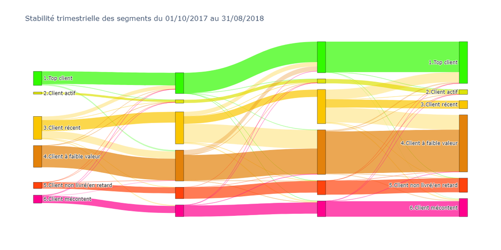

```python
Image("img/img_flow_customer.png")
```

Je constate aussi des effets à corriger :

- Les clients actifs qui sont très minoritaires,
- Des clients récents qui deviennent en quantité des clients à faible valeur.

Pour corriger cela, je préconise 3 actions majeures :

- Intégrer aux données l'origine des clients ; En effet, les clients se comportent différemments en fonction des place de marché. Il faut proposer une segmentation / analyse de stabilité par marketplaces,
- Mener des actions marketing ciblées adaptées à chacunes des plateformes de ventes,
- Auditer mensuellement la stabilité des segments, afin de suivre précisément les mouvements de marché par plateforme. Cela dans le but de proposer des actions correctives en cas de déviance.